# Final_AllLife_Bank_Project

## BACKGROUND AND CONTEXT

AllLife Bank is a US bank that has a growing customer base. The majority of these customers are liability customers (depositors) with varying sizes of deposits. The number of customers who are also borrowers (asset customers) is quite small, and the bank is interested in expanding this base rapidly to bring in more loan business and in the process, earn more through the interest on loans. In particular, the management wants to explore ways of converting its liability customers to personal loan customers (while retaining them as depositors).

A campaign that the bank ran last year for liability customers showed a healthy conversion rate of over 9% success. This has encouraged the retail marketing department to devise campaigns with better target marketing to increase the success ratio.

You as a Data scientist at AllLife bank have to build a model that will help the marketing department to identify the potential customers who have a higher probability of purchasing the loan.

### DATA DICTIONARY

- ID: Customer ID
- Age: Customer’s age in completed years
- Experience: #years of professional experience
- Income: Annual income of the customer (in thousand dollars)
- ZIP Code: Home Address ZIP code.
- Family: the Family size of the customer
- CCAvg: Average spending on credit cards per month (in thousand dollars)
- Education: Education Level. 1: Undergrad; 2: Graduate;3: Advanced/Professional
- Mortgage: Value of house mortgage if any. (in thousand dollars)
- Personal_Loan: Did this customer accept the personal loan offered in the last campaign?
- Securities_Account: Does the customer have securities account with the bank?
- CD_Account: Does the customer have a certificate of deposit (CD) account with the bank?
- Online: Do customers use internet banking facilities?
- CreditCard: Does the customer use a credit card issued by any other Bank (excluding All life Bank)?

### OBJECTIVE

- To predict whether a liability customer will buy a personal loan or not.
- Which variables are most significant.
- Which segment of customers should be targeted more.

### Importing Key Libraries

```python
import pandas as pd
import numpy as np
import seaborn as sns
import matplotlib.pyplot as plt
import warnings
warnings.filterwarnings('ignore')
from sklearn.model_selection import train_test_split
from sklearn import tree
from sklearn import metrics
from sklearn.tree import DecisionTreeClassifier
```

### Reading Dataset

```python
 L_data = pd.read_csv('Loan_Modelling.csv')
```

```python
# copying data to another varaible to avoid any changes to original data
df = L_data.copy()
```

### View the first and last 15 rows of the dataset.

```python
df.head(15)
```

|  | ID | Age | Experience | Income | ZIPCode | Family | CCAvg | Education | Mortgage | Personal_Loan | Securities_Account | CD_Account | Online | CreditCard |
| --- | --- | --- | --- | --- | --- | --- | --- | --- | --- | --- | --- | --- | --- | --- |
| 0 | 1 | 25 | 1 | 49 | 91107 | 4 | 1.6 | 1 | 0 | 0 | 1 | 0 | 0 | 0 |
| 1 | 2 | 45 | 19 | 34 | 90089 | 3 | 1.5 | 1 | 0 | 0 | 1 | 0 | 0 | 0 |
| 2 | 3 | 39 | 15 | 11 | 94720 | 1 | 1.0 | 1 | 0 | 0 | 0 | 0 | 0 | 0 |
| 3 | 4 | 35 | 9 | 100 | 94112 | 1 | 2.7 | 2 | 0 | 0 | 0 | 0 | 0 | 0 |
| 4 | 5 | 35 | 8 | 45 | 91330 | 4 | 1.0 | 2 | 0 | 0 | 0 | 0 | 0 | 1 |
| 5 | 6 | 37 | 13 | 29 | 92121 | 4 | 0.4 | 2 | 155 | 0 | 0 | 0 | 1 | 0 |
| 6 | 7 | 53 | 27 | 72 | 91711 | 2 | 1.5 | 2 | 0 | 0 | 0 | 0 | 1 | 0 |
| 7 | 8 | 50 | 24 | 22 | 93943 | 1 | 0.3 | 3 | 0 | 0 | 0 | 0 | 0 | 1 |
| 8 | 9 | 35 | 10 | 81 | 90089 | 3 | 0.6 | 2 | 104 | 0 | 0 | 0 | 1 | 0 |
| 9 | 10 | 34 | 9 | 180 | 93023 | 1 | 8.9 | 3 | 0 | 1 | 0 | 0 | 0 | 0 |
| 10 | 11 | 65 | 39 | 105 | 94710 | 4 | 2.4 | 3 | 0 | 0 | 0 | 0 | 0 | 0 |
| 11 | 12 | 29 | 5 | 45 | 90277 | 3 | 0.1 | 2 | 0 | 0 | 0 | 0 | 1 | 0 |
| 12 | 13 | 48 | 23 | 114 | 93106 | 2 | 3.8 | 3 | 0 | 0 | 1 | 0 | 0 | 0 |
| 13 | 14 | 59 | 32 | 40 | 94920 | 4 | 2.5 | 2 | 0 | 0 | 0 | 0 | 1 | 0 |
| 14 | 15 | 67 | 41 | 112 | 91741 | 1 | 2.0 | 1 | 0 | 0 | 1 | 0 | 0 | 0 |

```python
df.tail(15)
```

|  | ID | Age | Experience | Income | ZIPCode | Family | CCAvg | Education | Mortgage | Personal_Loan | Securities_Account | CD_Account | Online | CreditCard |
| --- | --- | --- | --- | --- | --- | --- | --- | --- | --- | --- | --- | --- | --- | --- |
| 4985 | 4986 | 48 | 23 | 30 | 94720 | 3 | 1.70 | 2 | 162 | 0 | 0 | 0 | 1 | 0 |
| 4986 | 4987 | 32 | 6 | 78 | 95825 | 1 | 2.90 | 3 | 0 | 0 | 0 | 0 | 0 | 0 |
| 4987 | 4988 | 48 | 23 | 43 | 93943 | 3 | 1.70 | 2 | 159 | 0 | 0 | 0 | 1 | 0 |
| 4988 | 4989 | 34 | 8 | 85 | 95134 | 1 | 2.50 | 1 | 136 | 0 | 0 | 0 | 0 | 1 |
| 4989 | 4990 | 24 | 0 | 38 | 93555 | 1 | 1.00 | 3 | 0 | 0 | 0 | 0 | 1 | 0 |
| 4990 | 4991 | 55 | 25 | 58 | 95023 | 4 | 2.00 | 3 | 219 | 0 | 0 | 0 | 0 | 1 |
| 4991 | 4992 | 51 | 25 | 92 | 91330 | 1 | 1.90 | 2 | 100 | 0 | 0 | 0 | 0 | 1 |
| 4992 | 4993 | 30 | 5 | 13 | 90037 | 4 | 0.50 | 3 | 0 | 0 | 0 | 0 | 0 | 0 |
| 4993 | 4994 | 45 | 21 | 218 | 91801 | 2 | 6.67 | 1 | 0 | 0 | 0 | 0 | 1 | 0 |
| 4994 | 4995 | 64 | 40 | 75 | 94588 | 3 | 2.00 | 3 | 0 | 0 | 0 | 0 | 1 | 0 |
| 4995 | 4996 | 29 | 3 | 40 | 92697 | 1 | 1.90 | 3 | 0 | 0 | 0 | 0 | 1 | 0 |
| 4996 | 4997 | 30 | 4 | 15 | 92037 | 4 | 0.40 | 1 | 85 | 0 | 0 | 0 | 1 | 0 |
| 4997 | 4998 | 63 | 39 | 24 | 93023 | 2 | 0.30 | 3 | 0 | 0 | 0 | 0 | 0 | 0 |
| 4998 | 4999 | 65 | 40 | 49 | 90034 | 3 | 0.50 | 2 | 0 | 0 | 0 | 0 | 1 | 0 |
| 4999 | 5000 | 28 | 4 | 83 | 92612 | 3 | 0.80 | 1 | 0 | 0 | 0 | 0 | 1 | 1 |

```python
# Viewing a random sample iin the dataset
df.sample(10)
```

|  | ID | Age | Experience | Income | ZIPCode | Family | CCAvg | Education | Mortgage | Personal_Loan | Securities_Account | CD_Account | Online | CreditCard |
| --- | --- | --- | --- | --- | --- | --- | --- | --- | --- | --- | --- | --- | --- | --- |
| 2727 | 2728 | 45 | 19 | 69 | 90840 | 1 | 2.8 | 1 | 220 | 0 | 0 | 0 | 1 | 1 |
| 184 | 185 | 52 | 26 | 63 | 92717 | 2 | 1.5 | 2 | 0 | 0 | 1 | 0 | 1 | 0 |
| 3074 | 3075 | 39 | 15 | 31 | 95039 | 1 | 1.4 | 3 | 88 | 0 | 0 | 0 | 1 | 1 |
| 2937 | 2938 | 62 | 36 | 89 | 94022 | 2 | 2.0 | 1 | 0 | 0 | 0 | 0 | 1 | 1 |
| 3994 | 3995 | 42 | 18 | 88 | 92675 | 4 | 0.8 | 1 | 0 | 0 | 0 | 0 | 1 | 1 |
| 2094 | 2095 | 57 | 31 | 64 | 90024 | 3 | 2.5 | 1 | 208 | 0 | 0 | 0 | 0 | 1 |
| 3692 | 3693 | 57 | 33 | 64 | 94132 | 4 | 2.2 | 1 | 0 | 0 | 0 | 0 | 1 | 0 |
| 371 | 372 | 58 | 34 | 19 | 92029 | 4 | 0.7 | 1 | 0 | 0 | 0 | 0 | 0 | 0 |
| 1672 | 1673 | 48 | 23 | 173 | 94546 | 3 | 0.2 | 1 | 0 | 1 | 0 | 1 | 1 | 1 |
| 209 | 210 | 64 | 39 | 172 | 94707 | 4 | 3.1 | 1 | 282 | 1 | 0 | 1 | 1 | 1 |

### Observations

- Mortgage has '0'enteries and will be left so since mortgage is a matter of choice, hence no use filling in the mean/median
- Education is an ordered column with 1 being the lowest to 3 beingthe highest form of education attained
- ID will have to be drooped for a cleaner analysis
- The ZIP codes will be mapped to locations in the US as this will help the marketing team classify the customers for a more targeted campaign. This will then be converted to a Categorical variable for EDA and modeling purposes as well
- Since we are concerned with the propensity to purchase a loan product, Personal_Loan will be the dependent variable

### Understanding the shape of the dataset

```python
df.shape
```

```
(5000, 14)
```

- Dataset has 5,000 rows and 14 columns

### Let's check the duplicate data. And if any, we should remove it.

```python
df[df.duplicated()].count()
```

```
ID                    0
Age                   0
Experience            0
Income                0
ZIPCode               0
Family                0
CCAvg                 0
Education             0
Mortgage              0
Personal_Loan         0
Securities_Account    0
CD_Account            0
Online                0
CreditCard            0
dtype: int64
```

### Observation

- No Duplicates

### Check the data types of the columns for the dataset.

```python
df.info()
```

```
<class 'pandas.core.frame.DataFrame'>
RangeIndex: 5000 entries, 0 to 4999
Data columns (total 14 columns):
 #   Column              Non-Null Count  Dtype
---  ------              --------------  -----
 0   ID                  5000 non-null   int64
 1   Age                 5000 non-null   int64
 2   Experience          5000 non-null   int64
 3   Income              5000 non-null   int64
 4   ZIPCode             5000 non-null   int64
 5   Family              5000 non-null   int64
 6   CCAvg               5000 non-null   float64
 7   Education           5000 non-null   int64
 8   Mortgage            5000 non-null   int64
 9   Personal_Loan       5000 non-null   int64
 10  Securities_Account  5000 non-null   int64
 11  CD_Account          5000 non-null   int64
 12  Online              5000 non-null   int64
 13  CreditCard          5000 non-null   int64
dtypes: float64(1), int64(13)
memory usage: 547.0 KB
```

### Key Observations:

- Most of the data-types are either **int64** or **float64**.
- CCAvg is of float64 datatype
- The rest are all of datatype int64

### We should note the following:

- Being a Classification problem, our target variable ought to be converted to a Categorical variable
- The Personal_Loan variable is our target variable here and and is of a classs variable which would be converted to a categorical variable for further analysis.
- We already know that we convert the categorical data-types into suitable form using either the "LabelEncoder" or "OneHotEncoding". This will be done for the ZIP codes after conversion to States.

### Check for missing values

```python
df.isnull().sum()
```

```
ID                    0
Age                   0
Experience            0
Income                0
ZIPCode               0
Family                0
CCAvg                 0
Education             0
Mortgage              0
Personal_Loan         0
Securities_Account    0
CD_Account            0
Online                0
CreditCard            0
dtype: int64
```

- There are no missing values in the dataset

### Checking the number of unique values

```python
df.nunique()
```

```
ID                    5000
Age                     45
Experience              47
Income                 162
ZIPCode                467
Family                   4
CCAvg                  108
Education                3
Mortgage               347
Personal_Loan            2
Securities_Account       2
CD_Account               2
Online                   2
CreditCard               2
dtype: int64
```

### Observation

- There are 45 unique ages of the customers under consideration
- They have 47 distinct years of experience
- There are 467 distinct zip codes ( we would have to analyse this further to understand the distribution)
- There are 4 different family sizes

```python
# Assigning values to Education column for a proper EDA
# Education: Education Level. 1: Undergrad; 2: Graduate;3: Advanced/Professional
dict = {1: 'Undergrad', 2: 'Graduate',3: 'Advanced/Professional'}
df['Education'].replace(dict,inplace = True)
```

```python
df.head(5)
```

|  | ID | Age | Experience | Income | ZIPCode | Family | CCAvg | Education | Mortgage | Personal_Loan | Securities_Account | CD_Account | Online | CreditCard |
| --- | --- | --- | --- | --- | --- | --- | --- | --- | --- | --- | --- | --- | --- | --- |
| 0 | 1 | 25 | 1 | 49 | 91107 | 4 | 1.6 | Undergrad | 0 | 0 | 1 | 0 | 0 | 0 |
| 1 | 2 | 45 | 19 | 34 | 90089 | 3 | 1.5 | Undergrad | 0 | 0 | 1 | 0 | 0 | 0 |
| 2 | 3 | 39 | 15 | 11 | 94720 | 1 | 1.0 | Undergrad | 0 | 0 | 0 | 0 | 0 | 0 |
| 3 | 4 | 35 | 9 | 100 | 94112 | 1 | 2.7 | Graduate | 0 | 0 | 0 | 0 | 0 | 0 |
| 4 | 5 | 35 | 8 | 45 | 91330 | 4 | 1.0 | Graduate | 0 | 0 | 0 | 0 | 0 | 1 |

## Fixing Data Types

```python
# We are fixing datatypes prior to Exploratory Data Analysis. We will reconvert back to numericals prior to modeling
df['Personal_Loan']= df['Personal_Loan'].astype('category')
df['Education']= df['Education'].astype('category')
df['Securities_Account']= df['Securities_Account'].astype('category')
df['CD_Account']= df['CD_Account'].astype('category')
df['Online'] = df['Online'].astype('category')
df['ZIPCode'] = df['ZIPCode'].astype('category')
df['CreditCard']= df['CreditCard'].astype('category')
```

```python
# Filtering the Categorical columns
cat_columns = df.describe(include=['category']).columns
cat_columns
```

```
Index(['ZIPCode', 'Education', 'Personal_Loan', 'Securities_Account',
       'CD_Account', 'Online', 'CreditCard'],
      dtype='object')
```

```python
# To det. number of values in descending order  in details as well as unique values for the the cat.columns
for i in cat_columns:
    print('Unique values in',i, 'are :')
    print(df[i].value_counts())
    print('*'*50)
```

```
Unique values in ZIPCode are :
94720    169
94305    127
95616    116
90095     71
93106     57
        ...
94598      1
94965      1
94970      1
90068      1
90813      1
Name: ZIPCode, Length: 467, dtype: int64
Unique values in Education are :
Undergrad                2096
Advanced/Professional    1501
Graduate                 1403
Name: Education, dtype: int64
Unique values in Personal_Loan are :
0    4520
1     480
Name: Personal_Loan, dtype: int64
Unique values in Securities_Account are :
0    4478
1     522
Name: Securities_Account, dtype: int64
Unique values in CD_Account are :
0    4698
1     302
Name: CD_Account, dtype: int64
Unique values in Online are :
1    2984
0    2016
Name: Online, dtype: int64
Unique values in CreditCard are :
0    3530
1    1470
Name: CreditCard, dtype: int64
```

### Observation

- There are more Undergrads in the population than other classes under Education
- 4,520 customers did not accept the Personal loan in the last campaign against 480 who did
- 4,478 customers do not maintain a security account against 522 who do
- 4,698 customers do not maintain a deposit with the bank against 302 who do
- Of the liability customers,2,984 use online facilities against 2016 who don't
- 3,530 of the customers do not maintain a credit card with other banks against 1,470 who do

```python
# Dropping the ID column as it is not relevant for our analysis
df.drop('ID',axis=1,inplace=True)
```

```python
df.info()
```

```
<class 'pandas.core.frame.DataFrame'>
RangeIndex: 5000 entries, 0 to 4999
Data columns (total 13 columns):
 #   Column              Non-Null Count  Dtype
---  ------              --------------  -----
 0   Age                 5000 non-null   int64
 1   Experience          5000 non-null   int64
 2   Income              5000 non-null   int64
 3   ZIPCode             5000 non-null   category
 4   Family              5000 non-null   int64
 5   CCAvg               5000 non-null   float64
 6   Education           5000 non-null   category
 7   Mortgage            5000 non-null   int64
 8   Personal_Loan       5000 non-null   category
 9   Securities_Account  5000 non-null   category
 10  CD_Account          5000 non-null   category
 11  Online              5000 non-null   category
 12  CreditCard          5000 non-null   category
dtypes: category(7), float64(1), int64(5)
memory usage: 297.8 KB
```

### Statistical summary of the Dataset

```python
df.describe(include='all').T
```

|  | count | unique | top | freq | mean | std | min | 25% | 50% | 75% | max |
| --- | --- | --- | --- | --- | --- | --- | --- | --- | --- | --- | --- |
| Age | 5000 | NaN | NaN | NaN | 45.3384 | 11.4632 | 23 | 35 | 45 | 55 | 67 |
| Experience | 5000 | NaN | NaN | NaN | 20.1046 | 11.468 | -3 | 10 | 20 | 30 | 43 |
| Income | 5000 | NaN | NaN | NaN | 73.7742 | 46.0337 | 8 | 39 | 64 | 98 | 224 |
| ZIPCode | 5000 | 467 | 94720 | 169 | NaN | NaN | NaN | NaN | NaN | NaN | NaN |
| Family | 5000 | NaN | NaN | NaN | 2.3964 | 1.14766 | 1 | 1 | 2 | 3 | 4 |
| CCAvg | 5000 | NaN | NaN | NaN | 1.93794 | 1.74766 | 0 | 0.7 | 1.5 | 2.5 | 10 |
| Education | 5000 | 3 | Undergrad | 2096 | NaN | NaN | NaN | NaN | NaN | NaN | NaN |
| Mortgage | 5000 | NaN | NaN | NaN | 56.4988 | 101.714 | 0 | 0 | 0 | 101 | 635 |
| Personal_Loan | 5000 | 2 | 0 | 4520 | NaN | NaN | NaN | NaN | NaN | NaN | NaN |
| Securities_Account | 5000 | 2 | 0 | 4478 | NaN | NaN | NaN | NaN | NaN | NaN | NaN |
| CD_Account | 5000 | 2 | 0 | 4698 | NaN | NaN | NaN | NaN | NaN | NaN | NaN |
| Online | 5000 | 2 | 1 | 2984 | NaN | NaN | NaN | NaN | NaN | NaN | NaN |
| CreditCard | 5000 | 2 | 0 | 3530 | NaN | NaN | NaN | NaN | NaN | NaN | NaN |

## Exploratory Data Analysis (EDA)

### Univariate analysis - Numericals

```python
# While doing uni-variate analysis of numerical variables we want to study their central tendency
# and dispersion.
# Let us write a function that will help us create boxplot and histogram for any input numerical
# variable.
# This function takes the numerical column as the input and returns the boxplots
# and histograms for the variable.
# Let us see if this help us write faster and cleaner code.
def histogram_boxplot(feature, figsize=(15,10), bins = None):
    """ Boxplot and histogram combined
    feature: 1-d feature array
    figsize: size of fig (default (9,8))
    bins: number of bins (default None / auto)
    """
    f2, (ax_box2, ax_hist2) = plt.subplots(nrows = 2, # Number of rows of the subplot grid= 2
                                           sharex = True, # x-axis will be shared among all subplots
                                           gridspec_kw = {"height_ratios": (.25, .75)},
                                           figsize = figsize
                                           ) # creating the 2 subplots
    sns.boxplot(feature, ax=ax_box2, showmeans=True, color='violet') # boxplot will be created and a star will indicate the mean value of the column
    sns.distplot(feature, kde=F, ax=ax_hist2, bins=bins,palette="winter") if bins else sns.distplot(feature, kde=False, ax=ax_hist2) # For histogram
    ax_hist2.axvline(np.mean(feature), color='green', linestyle='--') # Add mean to the histogram
    ax_hist2.axvline(np.median(feature), color='black', linestyle='-') # Add median to the histogram
```

### AGE

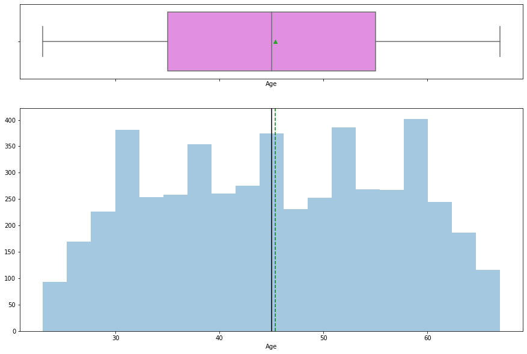

```python
histogram_boxplot(df["Age"])
plt.savefig("Plt_A.png")
plt.show()
```

### EXPERIENCE

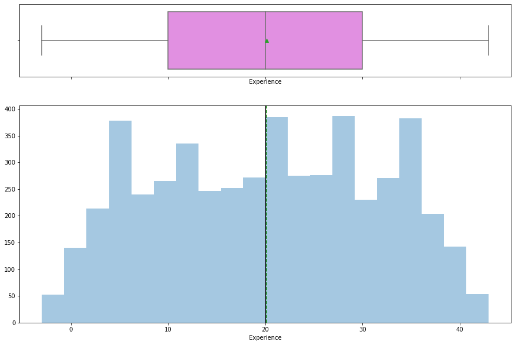

```python
histogram_boxplot(df["Experience"])
plt.savefig("Plt_Ex.png")
plt.show()
```

### INCOME

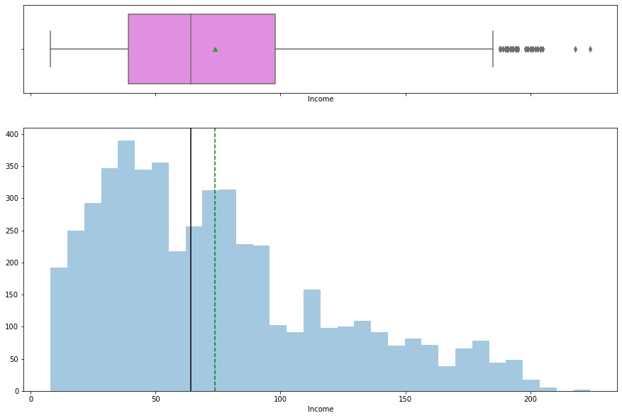

```python
histogram_boxplot(df["Income"])
plt.savefig("Plt_I.png")
plt.show()
```

- The distribution of Income is highly right-skewed.
- There are tremendous outliers in this variable.As is expected in reality
- The maximum income is 224,000 compared to a predominance of roughly 74,000( Mean income) indcating quite a high earning customer base
- The lowest income comes in at a paltry 8,000

#### Investigating Income Further and trying to minimise/correct skewness due to heavy outlier presence

### Income LogTransformation

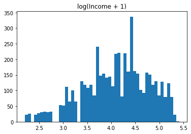

```python
plt.hist(np.log(df['Income'] + 1), 50)
plt.title('log(Income + 1)')
plt.savefig('Plt_InLogt')
plt.show()
```

### FAMILY

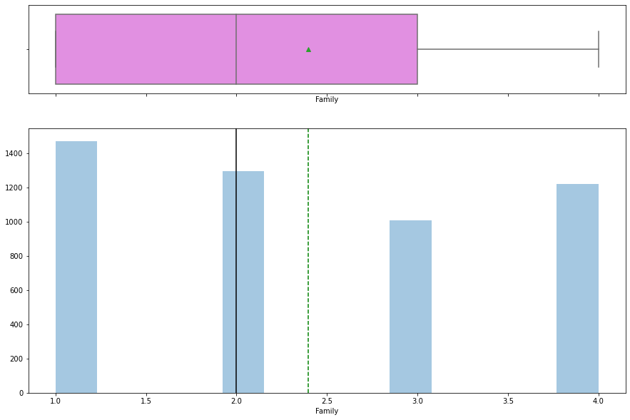

```python
histogram_boxplot(df["Family"])
plt.savefig("Plt_F.png")
plt.show()
```

### CCAvg

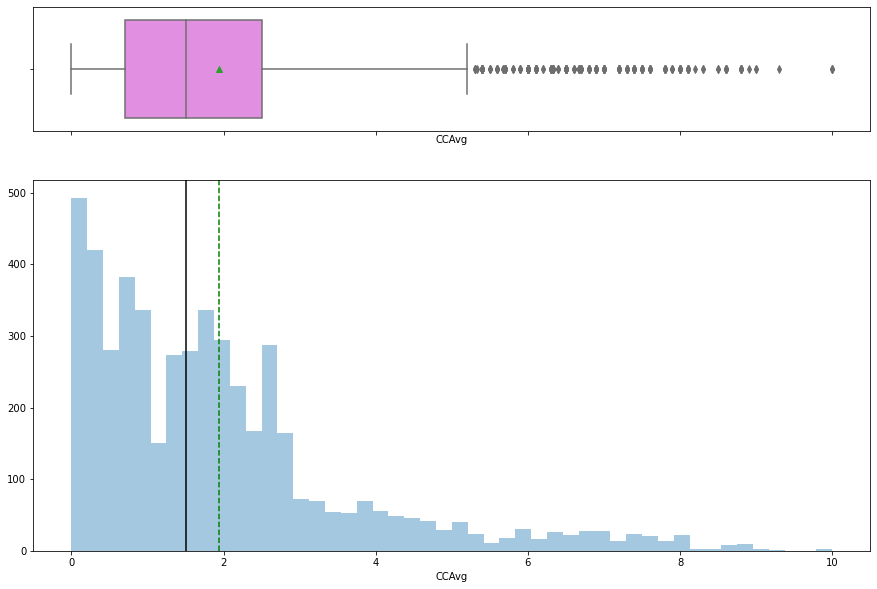

```python
histogram_boxplot(df["CCAvg"])
plt.savefig("Plt_CCAvg.png")
plt.show()
```

- The distribution of Credit Card spending is unusually right-skewed.
- There are unparalel outliers in this variable.
- 75% of the liability customers in the distribution spent 2,500 or less from their credit cards with 1,930 dollars spent on the average

#### Investigating CCAvg Further and trying to minimise/correct skewness due to heavy outlier presence

### CCAvg LogTransformation

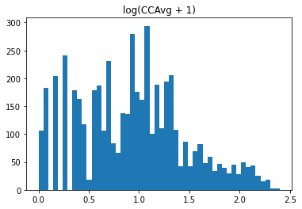

```python
plt.hist(np.log(df['CCAvg'] + 1), 50)
plt.title('log(CCAvg + 1)')
plt.savefig('Plt_CCLogt')
plt.show()
```

#### Observation

1. Note that the skewness has greatly been eliminated to affirm a Normal Distribution
2. CCAvg definitely behaves better on a Log scale

### MORTGAGE

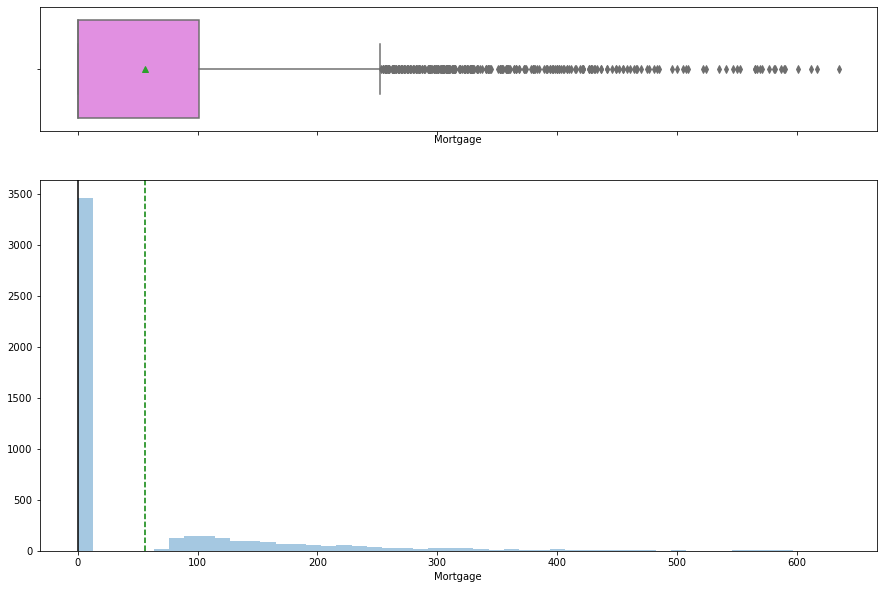

```python
histogram_boxplot(df["Mortgage"])
plt.savefig("Plt_M.png")
plt.show()
```

### Observation

- The distribution of Mortgage indicates is highly right-skewed.
- There are tremendous outliers in this variable.
- The maximum mortgage is 635,000 but a mean of 56,000.The range accounts for the evidence of the outliers seen here.
- Even though the 3rd Quartile indicates a mortgage value of 101,000, this does not apply to a significant number of the distribution from the 50th percentile who do not have a mortgage with zero value
- This clearly points to a less geared population of libility customers who are not indebted

#### Investigating Mortgage Further and trying to minimise/correct skewness due to heavy outlier presence

### Mortgage LogTransformation

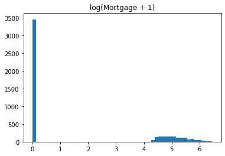

```python
plt.hist(np.log(df['Mortgage'] + 1), 50)
plt.title('log(Mortgage + 1)')
plt.savefig('Plt_MLogt')
plt.show()
```

#### Observation

- Note that the Log Transformationhad little or no effect clearly because a significant number had no mortgage

### Univariate Analysis - Categorical

```python
# Function to create barplots that indicate percentage for each category.

def perc_on_bar(plot, feature):
    '''
    plot
    feature: categorical feature
    the function won't work if a column is passed in hue parameter
    '''
    total = len(feature) # length of the column
    for p in ax.patches:
        percentage = '{:.1f}%'.format(100 * p.get_height()/total) # percentage of each class of the category
        x = p.get_x() + p.get_width() / 2 - 0.05 # width of the plot
        y = p.get_y() + p.get_height()           # hieght of the plot
        ax.annotate(percentage, (x, y), size = 12) # annotate the percantage
    plt.show() # show the plot
```

### PERSONAL LOAN

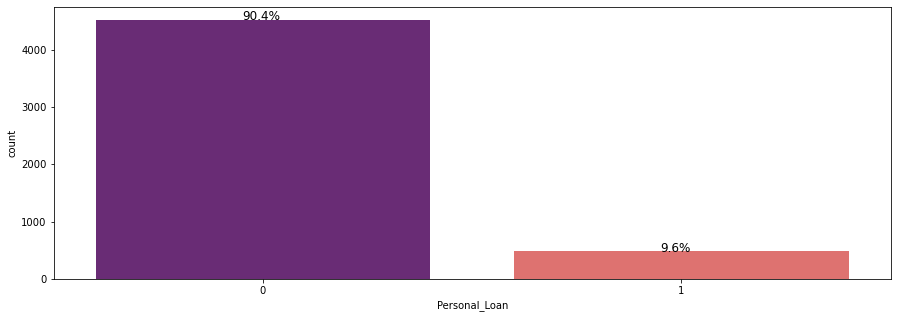

```python
plt.figure(figsize=(15,5))
ax = sns.countplot(df["Personal_Loan"], palette='magma')
perc_on_bar(ax,df["Personal_Loan"])
plt.savefig('Plt_PL.png')
```

### Observation

- 90.4% of the customers did not accept the personal loans in the last campaign.
- 9.6% of the customers accepted personal loans previously

### EDUCATION

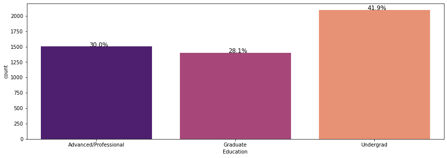

```python
plt.figure(figsize=(15,5))
ax = sns.countplot(df["Education"], palette='magma')
perc_on_bar(ax,df["Education"])
plt.savefig('Plt_ED.png')
```

### Observation

- 41.9% of the customers are Undergrads with Advanced/Professional following closely indicating the website has a loyal base of customers.
- Graduate Education accounts for 28.1% of the distribution of customers

### SECURITIES_ACCOUNT

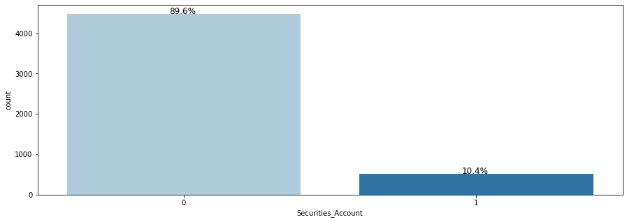

```python
plt.figure(figsize=(15,5))
ax = sns.countplot(df["Securities_Account"], palette='Paired')
perc_on_bar(ax,df["Securities_Account"])
plt.savefig('Plt_SA.png')
```

### Observation

- 89.6% of the customersdo not maintain a security account with AllLife Bank while 10.4% does.

### CD_ACCOUNT

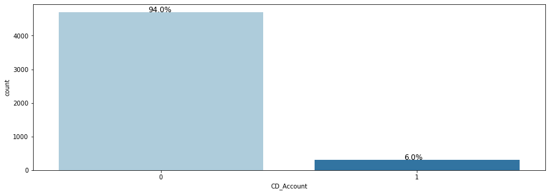

```python
plt.figure(figsize=(15,5))
ax = sns.countplot(df["CD_Account"], palette='Paired')
perc_on_bar(ax,df["CD_Account"])
plt.savefig('Plt_CD.png')
```

### Observation

- 94.0% do not maintain a Certificate of Deposit account with AllLife Bank while 6.0% does.

### ONLINE

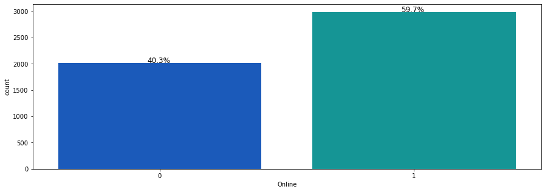

```python
plt.figure(figsize=(15,5))
ax = sns.countplot(df["Online"], palette='winter')
perc_on_bar(ax,df["Online"])
plt.savefig('Plt_On.png')
```

### Observation

- 40.3% of the customers of AllLife Bank do not use online banking facilities while 59.7% engage online banking facilities.

### CREDIT CARD

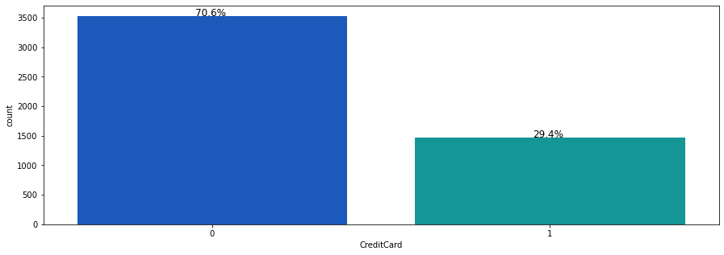

```python
plt.figure(figsize=(15,5))
ax = sns.countplot(df["CreditCard"], palette='winter')
perc_on_bar(ax,df["CreditCard"])
plt.savefig('Plt_CC.png')
```

### Observation

- 70.6% of the customers do not use credit cards issued by other banks while 29.4% do

[figure not shown]

```python
plt.figure(figsize=(15,5))
ax = sns.countplot(df["ZIPCode"], palette='winter')
perc_on_bar(ax,df["ZIPCode"])
plt.savefig('Plt_ZIP.png')
```

## Bivariate Analysis

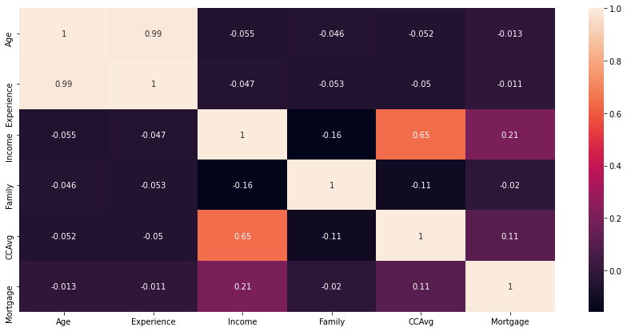

```python
plt.figure(figsize=(15,7))
sns.heatmap(df.corr(),annot=True)
plt.savefig('Plt_Hm.png')
plt.show()
```

### Observation

- We can immediately infer a strong correlation between Age and Experience
- Same can be concluded for CCAvg and Income. This clearly alludes to the fact that the higher the income, the higher the propensity for credit card spending
- There is a relatively fair correlation between Mortgage and Income. This establishes that a higher income would ideally endear the management of AllLife Bank to finance a mortgage facility
- There is clearly little or no correlation between the other variables
- We can see varying distributions in variables for revenue, we should investigate it further.

### Personal Loan vs Income, CCAvg and Mortgage with outliers

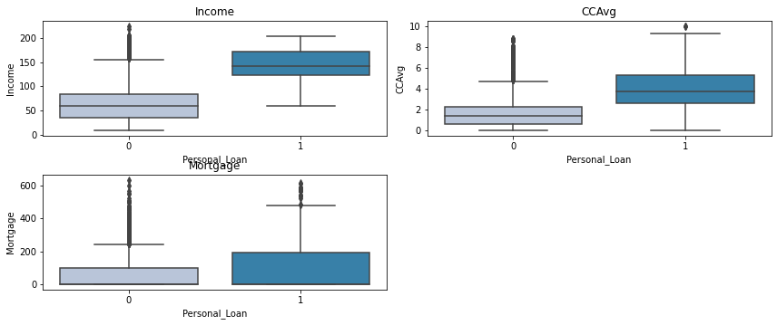

```python
cols = df[['Income','CCAvg','Mortgage']].columns.tolist()
plt.figure(figsize=(12,7))

for i, variable in enumerate(cols):
                     plt.subplot(3,2,i+1)
                     sns.boxplot(df["Personal_Loan"],df[variable],palette="PuBu")
                     plt.tight_layout()
                     plt.title(variable)

plt.savefig('Plt_ICMo.png')
plt.show()
```

- Let us get a better understanding from the plots by removing the outliers (for visualization not from original data)

### Personal Loan vs Income vs CCAvg vs Mortgage without outliers

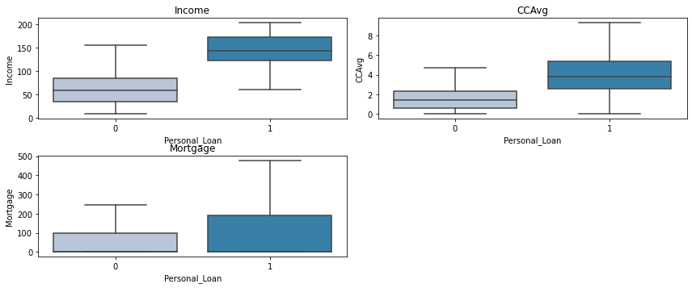

```python
cols = df[['Income','CCAvg','Mortgage']].columns.tolist()
plt.figure(figsize=(12,7))

for i, variable in enumerate(cols):
                     plt.subplot(3,2,i+1)
                     sns.boxplot(df["Personal_Loan"],df[variable],palette="PuBu",showfliers=False)
                     plt.tight_layout()
                     plt.title(variable)
plt.savefig('Plt_ICMw.png')
plt.show()
```

### Observation

- Liability customers with higher incomes, higher credit card spending and higher mortgages are huge potentials for to purchase personal loans in the next campaign
- This further validates the correlation between Income, CCAvgand Mortgage
- The management of AllLife Bank would be more akin to disburse loans to customers with higher incomes who equally have higher credit card spending apetites
- Customers with higher credit card spending and mortgge with attract more fees and ultimatlely income for AllLife Bank in the event that they subscribe to the next personal loan campaign

### Personal Loan vs Age vs Experience

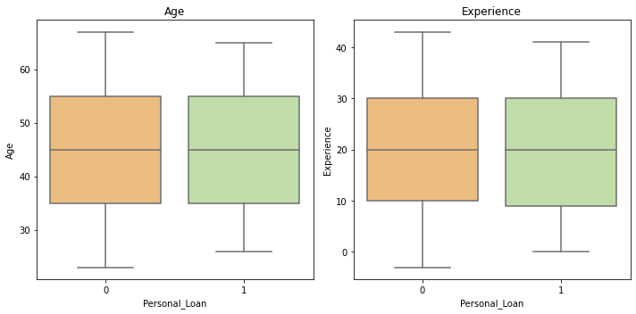

```python
cols = df[['Age','Experience']].columns.tolist()
plt.figure(figsize=(10,5))

for i, variable in enumerate(cols):
                     plt.subplot(1,2,i+1)
                     sns.boxplot(df["Personal_Loan"],df[variable],palette="Spectral")
                     plt.tight_layout()
                     plt.title(variable)
plt.savefig('Plt_AE.png')
plt.show()
```

### Observation

- Here again , we see the obvious correlation between Age and Experience
- The interesting pattern here indicates an equal drive on Personal Loan potentiials for both classes of customers who did not accept loan offers at the previous campaign
- The affinity of AllLife Bank management to sella personal loan to customers with a high professional experience is high compared to that below 10 years
- Same applies to one with an age of 35 and above who did not accept a personal loan offer

### Personal Loan vs Family

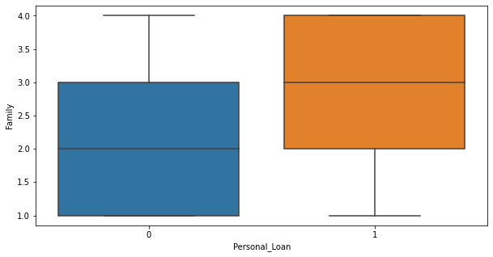

```python
plt.figure(figsize=(10,5))
sns.boxplot(df['Personal_Loan'],df['Family'])
plt.savefig('Plt_PF.png')
plt.show()
```

### Observation

- Liability customers with family sizes of 2 or more accessed personal loans in the last campaign
- While 50% at least of those who did not have a family size of 2 or less

```python
## We are using a stacked plot for an indepth analysis and visualisation of Bivariate analysis of Cat. variables

def stacked_plot(x):
    sns.set(palette='nipy_spectral')
    tab1 = pd.crosstab(x,df['Personal_Loan'],margins=True)
    print(tab1)
    print('-'*120)
    tab = pd.crosstab(x,df['Personal_Loan'],normalize='index')
    tab.plot(kind='bar',stacked=True,figsize=(10,5))
    plt.legend(loc='lower left', frameon=False)
    plt.legend(loc="upper left", bbox_to_anchor=(1,1))
    plt.show()
```

## Personal Loan vs Education

```
Personal_Loan             0    1   All
Education
Advanced/Professional  1296  205  1501
Graduate               1221  182  1403
Undergrad              2003   93  2096
All                    4520  480  5000
------------------------------------------------------------------------------------------------------------------------
```

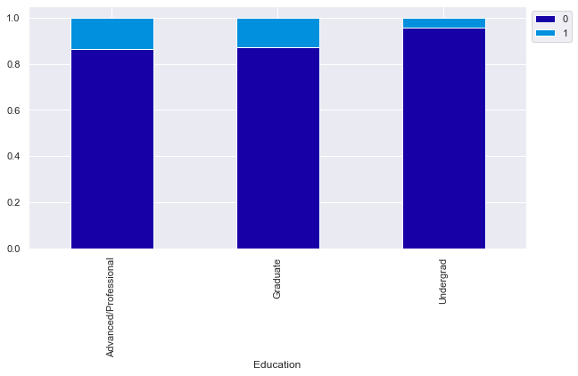

```python
stacked_plot(df['Education'])
plt.savefig('SPlt_ED.png')
plt.show()
```

### Observation

- Undergrads return the highest numbers of potentials of an untapped market.The plot tells us they have the highest bracket of those who did not access the personal loan of the previous campaign.
- Advanced professionals leads the pack with roughly 15% chance of beign granted loan offers compared to Graduates with a 13%
- This speaks to the potential of a huge market for AllLife Bank

### Personal Loan vs Securities_Account

```
Personal_Loan          0    1   All
Securities_Account
0                   4058  420  4478
1                    462   60   522
All                 4520  480  5000
------------------------------------------------------------------------------------------------------------------------
```

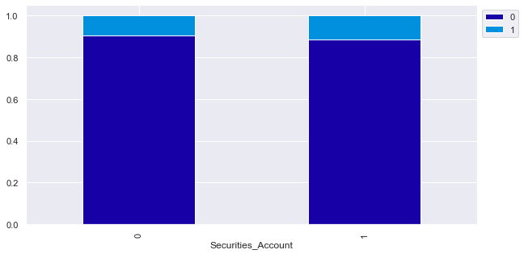

```python
stacked_plot(df['Securities_Account'])
plt.savefig('SPlt_SA.png')
plt.show()
```

## Personal Loan vs CD_Account

```
Personal_Loan     0    1   All
CD_Account
0              4358  340  4698
1               162  140   302
All            4520  480  5000
------------------------------------------------------------------------------------------------------------------------
```

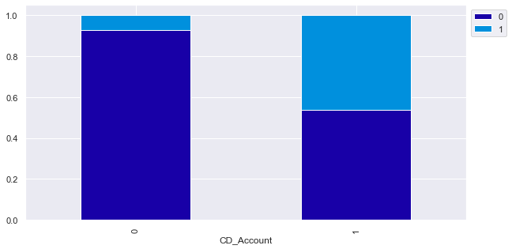

```python
stacked_plot(df['CD_Account'])
plt.savefig('SPlt_CD.png')
plt.show()
```

### Observation

- Customers without Certificate of deposits accessed fewer loans compared with those with Certificate of deposits with a likelihood of roughly 7%
- Customers with Certificate of Deposits have a 50% chance of being offered a Personal Loan

### Personal Loan vs Online

```
Personal_Loan     0    1   All
Online
0              1827  189  2016
1              2693  291  2984
All            4520  480  5000
------------------------------------------------------------------------------------------------------------------------
```

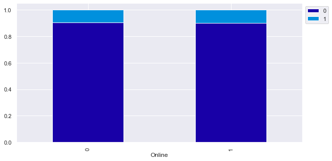

```python
stacked_plot(df['Online'])
plt.savefig('SPlt_ON.png')
plt.show()
```

### Observation

- Customers without online banking activities who accessed loans (189) are reltively fewer compared with those that have online banking activities (291)
- Customers who engage in online banking activities have an almost at per chances of being considered for a loan purchase when compared to those without
- This stands at approx. 10% and 9% respectively

### Personal Loan vs Credit Card

```
Personal_Loan     0    1   All
CreditCard
0              3193  337  3530
1              1327  143  1470
All            4520  480  5000
------------------------------------------------------------------------------------------------------------------------
```

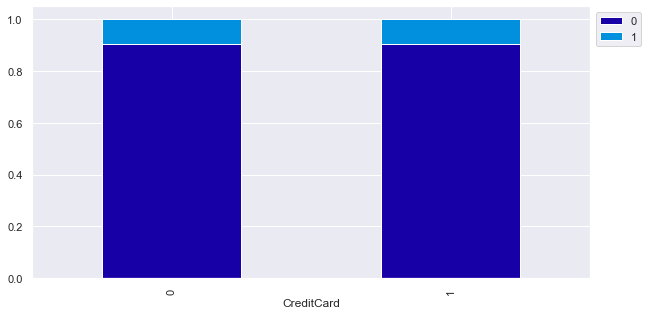

```python
stacked_plot(df['CreditCard'])
plt.savefig('SPlt_CC.png')
plt.show()
```

### Observation

- There is a similar distrbution in Credit card spending between both classes
- This also speaks to huge potentioal in both classes

### Let us study Age Distribution by Education to understand the mix

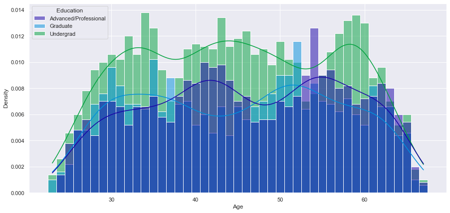

```python
plt.figure(figsize=(15,7))
sns.histplot(df, x="Age", hue="Education",stat='density',kde=True,discrete=True);
plt.savefig('kde_Plt_AE.png')
plt.show()
```

### Observation

- Advanced Professionals maintain a higher age compared to others when considered for loan purchase

### Let us also study the Age Distribution by Personal Loan

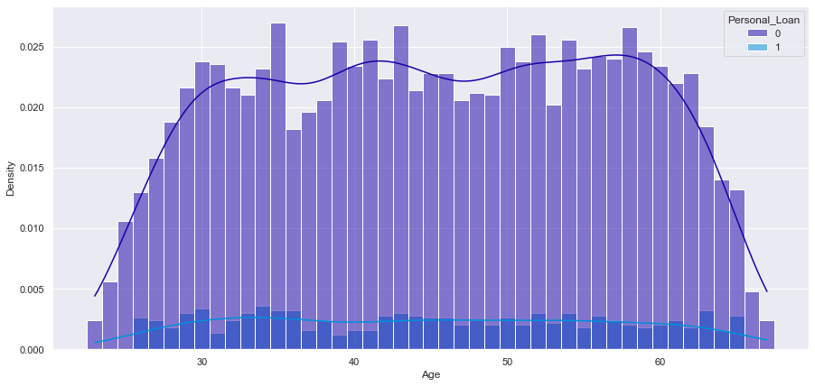

```python
plt.figure(figsize=(15,7))
sns.histplot(df, x="Age", hue="Personal_Loan",stat='density',kde=True,discrete=True);
plt.savefig('kde_Plt_AP.png')
plt.show()
```

### Observation

- It is clear that those who took loans are lesser in number compared to those who did not considering the age factor

### Let us study Experience by Personal Loan

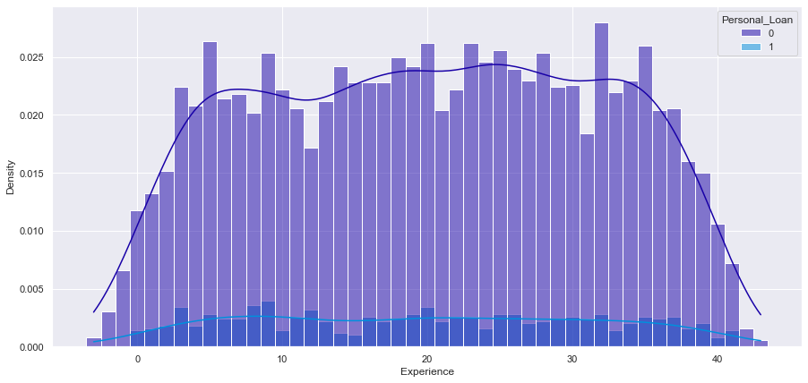

```python
plt.figure(figsize=(15,7))
sns.histplot(df, x="Experience", hue="Personal_Loan",stat='density',kde=True,discrete=True);
plt.savefig('kde_Plt_EP.png')
plt.show()
```

### Let us study Income by Personal Loan

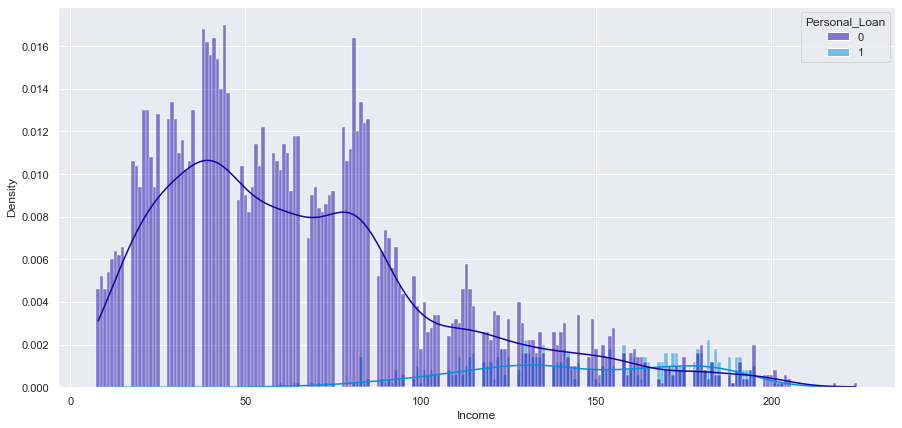

```python
plt.figure(figsize=(15,7))
sns.histplot(df, x="Income", hue="Personal_Loan",stat='density',kde=True,discrete=True);
plt.savefig('kde_Plt_IP.png')
plt.show()
```

### Observation

- Income is a major determinant for Loan Purchase
- Customers with higher income far trumps those without considering loan offers

### Customer-Level Analysis

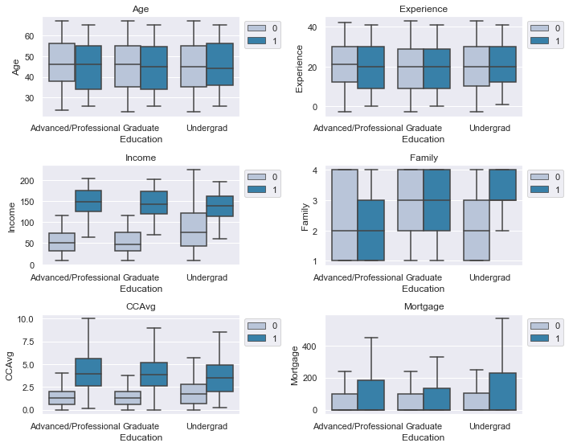

```python
cols = df[['Age','Experience','Income','Family',
             'CCAvg','Mortgage']].columns.tolist()
plt.figure(figsize=(10,10))

for i, variable in enumerate(cols):
                     plt.subplot(4,2,i+1)
                     sns.boxplot(df["Education"],df[variable],hue=df['Personal_Loan'],
                                 palette="PuBu", showfliers=False) #turning-off outliers
                     plt.tight_layout()
                     plt.legend(loc="upper left", bbox_to_anchor=(1,1))
                     plt.title(variable)

plt.savefig('Plt_CLA_EPL.png')
plt.show()
```

### Calculate Loan Ratio of Outcome variable

```python
n_true = len(df.loc[df['Personal_Loan'] == 1])
n_false = len(df.loc[df['Personal_Loan'] == 0])
print("Number of true cases: {0} ({1:2.2f}%)".format(n_true, (n_true / (n_true + n_false)) * 100 ))
print("Number of false cases: {0} ({1:2.2f}%)".format(n_false, (n_false / (n_true + n_false)) * 100))
```

```
Number of true cases: 480 (9.60%)
Number of false cases: 4520 (90.40%)
```

### Observation

- So we have 9.60% of liability customers in current data set who accepted personalloans at the previous campaign against 90.40% who did not.
- This is a highly biased distribution in the dataset. As such we will attend to this when building our decision tree

### Data Preperation

#### Investigating anomaly in the Experience column

```python
# Treating the Experience Column with negative values
# We first identify the rows with negative values and drop them since they were erroroneus datapoints clearly
err_val= (df.loc[df['Experience']<0])
len(err_val)
```

```
52
```

```python
err_val['Experience'].value_counts()
```

```
-1    33
-2    15
-3     4
Name: Experience, dtype: int64
```

```python
## Dropping all rows containing the negative values
df = df[df['Experience'] != -1]
df = df[df['Experience'] != -2]
df = df[df['Experience'] != -3]
```

```python
df[df['Experience']<0]['Experience'].count()
```

```
0
```

```python
# ZIPCode values has no information related to the purchase potential of a customer and would create a bias in model.
df = df.drop(['ZIPCode'],axis=1)
```

```python
# Converting the Education variable to dummy variable
model_data = pd.get_dummies(df, columns=['Education'],drop_first=True)
LR_data = model_data.copy()
LR_data.head()
```

|  | Age | Experience | Income | Family | CCAvg | Mortgage | Personal_Loan | Securities_Account | CD_Account | Online | CreditCard | Education_Graduate | Education_Undergrad |
| --- | --- | --- | --- | --- | --- | --- | --- | --- | --- | --- | --- | --- | --- |
| 0 | 25 | 1 | 49 | 4 | 1.6 | 0 | 0 | 1 | 0 | 0 | 0 | 0 | 1 |
| 1 | 45 | 19 | 34 | 3 | 1.5 | 0 | 0 | 1 | 0 | 0 | 0 | 0 | 1 |
| 2 | 39 | 15 | 11 | 1 | 1.0 | 0 | 0 | 0 | 0 | 0 | 0 | 0 | 1 |
| 3 | 35 | 9 | 100 | 1 | 2.7 | 0 | 0 | 0 | 0 | 0 | 0 | 1 | 0 |
| 4 | 35 | 8 | 45 | 4 | 1.0 | 0 | 0 | 0 | 0 | 0 | 1 | 1 | 0 |

```python
column_names = list(LR_data.columns)
column_names.remove('Personal_Loan')# Keep only names of features by removing the name of target variable
feature_names = column_names
print(feature_names)
```

```
['Age', 'Experience', 'Income', 'Family', 'CCAvg', 'Mortgage', 'Securities_Account', 'CD_Account', 'Online', 'CreditCard', 'Education_Graduate', 'Education_Undergrad']
```

## 1. Logistic Regression Using sklearn

1. Data preparation
2. Partition the data into train and test set.
3. Investigate Model Performance
4. Predict on Train and Test Data
5. Check Multicollinearity
6. Build Model

## 2. CART Approach

1. Data preparation
2. Partition the data into train and test set.
3. Built a CART model on the train data.
4. Tune the model and prune the tree, if required.
5. Test the data on test set.

### Logistic Regression (Sklearn)

#### Let us create a function that will Split, Encode and add a constant to X

#### The function will save us time iterting VIF values and check model performance

```python
# We will use 70% of data for training and 30% for testing.
from statsmodels.tools.tools import add_constant

def split(*kwargs):
    '''
    Function to split data into X and Y then one hot encode the X variable.
    Returns training and test sets
    *kwargs : Variable to remove from the dataset before splitting into X and Y
    '''
    X = LR_data.drop([*kwargs], axis=1)
    Y = LR_data['Personal_Loan']

    X = pd.get_dummies(X,drop_first=True)
    X = add_constant(X)

    #Splitting data in train and test sets
    X_train, X_test, y_train, y_test = train_test_split(X,Y, test_size=0.30, random_state = 1)
    return X_train,X_test, y_train, y_test
```

```python
X_train,X_test, y_train, y_test = split('Personal_Loan')
```

```python
# Let us check the split of the data
print("{0:0.2f}% data is in training set".format((len(X_train)/len(LR_data.index)) * 100))
print("{0:0.2f}% data is in test set".format((len(X_test)/len(LR_data.index)) * 100))
```

```
69.99% data is in training set
30.01% data is in test set
```

```python
# Let us check the split in the test and train data
print("Original  True Values    : {0} ({1:0.2f}%)".format(len(LR_data.loc[LR_data['Personal_Loan'] == 1]), (len(LR_data.loc[LR_data['Personal_Loan'] == 1])/len(LR_data.index)) * 100))
print("Original  False Values   : {0} ({1:0.2f}%)".format(len(LR_data.loc[LR_data['Personal_Loan'] == 0]), (len(LR_data.loc[LR_data['Personal_Loan'] == 0])/len(LR_data.index)) * 100))
print("")
print("Training  True Values    : {0} ({1:0.2f}%)".format(len(y_train[y_train[:] == 1]), (len(y_train[y_train[:] == 1])/len(y_train)) * 100))
print("Training  False Values   : {0} ({1:0.2f}%)".format(len(y_train[y_train[:] == 0]), (len(y_train[y_train[:] == 0])/len(y_train)) * 100))
print("")
print("Test True Values        : {0} ({1:0.2f}%)".format(len(y_test[y_test[:] == 1]), (len(y_test[y_test[:] == 1])/len(y_test)) * 100))
print("Test False Values       : {0} ({1:0.2f}%)".format(len(y_test[y_test[:] == 0]), (len(y_test[y_test[:] == 0])/len(y_test)) * 100))
print("")
```

```
Original  True Values    : 480 (9.70%)
Original  False Values   : 4468 (90.30%)

Training  True Values    : 335 (9.67%)
Training  False Values   : 3128 (90.33%)

Test True Values        : 145 (9.76%)
Test False Values       : 1340 (90.24%)
```

### Building the Model

###### Model evaluation criterion

Model can make wrong predictions as:

```
Predicting a liability customer will not default on a personal loan but actually defaults.
Predicting a liability customer will default but actually does not.
```

Which case is more important?

Both the cases are important as:

```
If we predict a customer will not default but actually does, the customer will be blacklisted and resources deployed to recover the loan

If we predict a customer will default but actually doesn't (opportunity loss)
```

###### Which loss is greater ?

```
Lending to a customer who wouldn't fulfill a a Repayment of the loan.
```

###### How to reduce losses?

```
We can use accuracy but since the data is imbalanced it would not be the right metric to check the model performance.
Therefore, f1_score should be maximized, the greater the f1_score higher the chances of identifying both the classes correctly.
```

Similarly, since we want to reduce loan default we should use Recall as a metric of model evaluation instead of accuracy.

```python
from sklearn import metrics
from sklearn.linear_model import LogisticRegression

lr = LogisticRegression(solver='newton-cg',max_iter=1000,penalty='none',verbose=True,n_jobs=-1,random_state=1)

# There are several optimizer, we are using optimizer called as 'newton-cg' with max_iter equal to 10000
# max_iter indicates number of iteration needed to converge

lr.fit(X_train, y_train)
```

```
[Parallel(n_jobs=-1)]: Using backend LokyBackend with 2 concurrent workers.
[Parallel(n_jobs=-1)]: Done   1 out of   1 | elapsed:    9.5s finished
```

```
LogisticRegression(max_iter=1000, n_jobs=-1, penalty='none', random_state=1,
                   solver='newton-cg', verbose=True)
```

### Model Performances

#### Creating functions to calculate different metrics and confusion matrix so that we don't have to use the same code repeatedly for each model.

- The get_metrics_score1 function will be used to check the model performance of models built using the statsmodels library.
- The get_metrics_score2 function will be used to check the model performance of models built using the Sklearn library.

```python
#Accuracy with a threhold of 0.5
from sklearn.metrics import accuracy_score
from sklearn.metrics import recall_score
from sklearn.metrics import precision_score
from sklearn.metrics import f1_score
from sklearn.metrics import roc_auc_score

#The get_metrics_score1 function will be used to check the model performance of models built using the statsmodels library.
def get_metrics_score1(model,train,test,y_train,y_test,threshold=0.5,flag=True,roc=False):
    '''
    Function to calculate different metric scores of the model - Accuracy, Recall, Precision, and F1 score
    model: classifier to predict values of X
    train, test: Independent features
    train_y,test_y: Dependent variable
    threshold: thresold for classifiying the observation as 1
    flag: If the flag is set to True then only the print statements showing different will be displayed. The default value is set to True.
    roc: If the roc is set to True then only roc score will be displayed. The default value is set to False.
    '''
    # defining an empty list to store train and test results

    score_list=[]

    pred_train = (model.predict(train)>threshold)
    pred_test = (model.predict(test)>threshold)

    pred_train = np.round(pred_train)
    pred_test = np.round(pred_test)

    train_acc = accuracy_score(pred_train,y_train)
    test_acc = accuracy_score(pred_test,y_test)

    train_recall = recall_score(y_train,pred_train)
    test_recall = recall_score(y_test,pred_test)

    train_precision = precision_score(y_train,pred_train)
    test_precision = precision_score(y_test,pred_test)

    train_f1 = f1_score(y_train,pred_train)
    test_f1 = f1_score(y_test,pred_test)


    score_list.extend((train_acc,test_acc,train_recall,test_recall,train_precision,test_precision,train_f1,test_f1))


    if flag == True:
        print("Accuracy on training set : ",accuracy_score(pred_train,y_train))
        print("Accuracy on test set : ",accuracy_score(pred_test,y_test))
        print("Recall on training set : ",recall_score(y_train,pred_train))
        print("Recall on test set : ",recall_score(y_test,pred_test))
        print("Precision on training set : ",precision_score(y_train,pred_train))
        print("Precision on test set : ",precision_score(y_test,pred_test))
        print("F1 on training set : ",f1_score(y_train,pred_train))
        print("F1 on test set : ",f1_score(y_test,pred_test))

    if roc == True:
        print("ROC-AUC Score on training set : ",roc_auc_score(y_train,pred_train))
        print("ROC-AUC Score on test set : ",roc_auc_score(y_test,pred_test))

    return score_list # returning the list with train and test scores
```

```python
#The get_metrics_score2 function will be used to check the model performance of models built using the Sklearn library.
def get_metrics_score2(model,train,test,y_train,y_test,flag=True,roc=False):
    '''
    Function to calculate different metric scores of the model - Accuracy, Recall, Precision, and F1 score
    model: classifier to predict values of X
    train, test: Independent features
    train_y,test_y: Dependent variable
    flag: If the flag is set to True then only the print statements showing different will be displayed. The default value is set to True.
    roc: If the roc is set to True then only roc score will be displayed. The default value is set to False.
    '''
    # defining an empty list to store train and test results

    score_list=[]

    pred_train = model.predict(train)
    pred_test = model.predict(test)

    train_acc = accuracy_score(pred_train,y_train)
    test_acc = accuracy_score(pred_test,y_test)

    train_recall = recall_score(y_train,pred_train)
    test_recall = recall_score(y_test,pred_test)

    train_precision = precision_score(y_train,pred_train)
    test_precision = precision_score(y_test,pred_test)

    train_f1 = f1_score(y_train,pred_train)
    test_f1 = f1_score(y_test,pred_test)


    score_list.extend((train_acc,test_acc,train_recall,test_recall,train_precision,test_precision,train_f1,test_f1))

     # If the flag is set to True then only the following print statements will be dispayed. The default value is set to True.
    if flag == True:
        print("Accuracy on training set : ",accuracy_score(pred_train,y_train))
        print("Accuracy on test set : ",accuracy_score(pred_test,y_test))
        print("Recall on training set : ",recall_score(y_train,pred_train))
        print("Recall on test set : ",recall_score(y_test,pred_test))
        print("Precision on training set : ",precision_score(y_train,pred_train))
        print("Precision on test set : ",precision_score(y_test,pred_test))
        print("F1 on training set : ",f1_score(y_train,pred_train))
        print("F1 on test set : ",f1_score(y_test,pred_test))

    if roc == True:
        print("ROC-AUC Score on training set : ",roc_auc_score(y_train,pred_train))
        print("ROC-AUC Score on test set : ",roc_auc_score(y_test,pred_test))

    return score_list # returning the list with train and test scores
```

```python
#Predict for train set
pred_train = lr.predict(X_train)

from sklearn.metrics import classification_report,confusion_matrix
#mat_train = confusion_matrix(y_train,pred_train)


## Function to create confusion matrix
def make_confusion_matrix(y_actual,y_predict,labels=[1, 0]):
    '''
    y_predict: prediction of class
    y_actual : ground truth
    '''
    cm=confusion_matrix( y_actual,y_predict, labels=[1, 0])
    df_cm = pd.DataFrame(cm, index = [i for i in ["Actual 1","Actual 0"]],
                  columns = [i for i in ['Predict 1','Predict 0']])
    group_counts = ["{0:0.0f}".format(value) for value in
                cm.flatten()]
    group_percentages = ["{0:.2%}".format(value) for value in
                         cm.flatten()/np.sum(cm)]
    labels = [f"{v1}\n{v2}" for v1, v2 in
              zip(group_counts,group_percentages)]
    labels = np.asarray(labels).reshape(2,2)
    plt.figure(figsize = (10,7))
    sns.heatmap(df_cm, annot=labels,fmt='')
    plt.ylabel('True label')
    plt.xlabel('Predicted label')
```